# Model Serialization

Compare predictions

```python
bart_preds_deserialized = bart_model_deserialized.predict(X_test, basis_test)
y_hat_deserialized = bart_preds_deserialized['y_hat']
y_avg_mcmc_deserialized = np.squeeze(y_hat_deserialized).mean(axis=1, keepdims=True)
y_df = pd.DataFrame(
    np.concatenate((y_avg_mcmc, y_avg_mcmc_deserialized), axis=1),
    columns=["Original model", "Deserialized model"],
)
sns.scatterplot(data=y_df, x="Original model", y="Deserialized model")
plt.axline((0, 0), slope=1, color="black", linestyle=(0, (3, 3)))
plt.show()
```

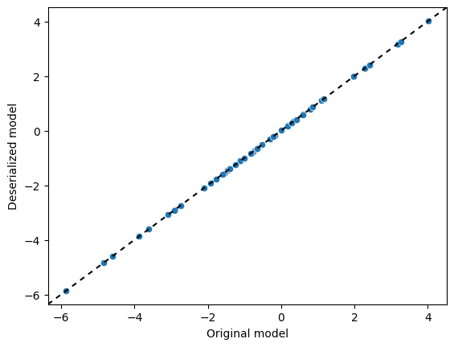

Compare parameter samples

```python
sigma2_df = pd.DataFrame(
    np.c_[bart_model.global_var_samples, bart_model_deserialized.global_var_samples],
    columns=["Original model", "Deserialized model"],
)
sns.scatterplot(data=sigma2_df, x="Original model", y="Deserialized model")
plt.axline((0, 0), slope=1, color="black", linestyle=(0, (3, 3)))
plt.show()
```

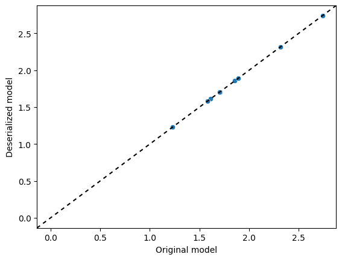

Save to JSON file

```python
with open("bart.json", "w") as f:
    bart_json_python = json.loads(bart_json_string)
    json.dump(bart_json_python, f)
```

Reload from JSON file

```python
with open("bart.json", "r") as f:
    bart_json_python_reload = json.load(f)
bart_json_string_reload = json.dumps(bart_json_python_reload)
bart_model_file_deserialized = BARTModel()
bart_model_file_deserialized.from_json(bart_json_string_reload)
```

Compare predictions

```python
bart_preds_file_deserialized = bart_model_file_deserialized.predict(X_test, basis_test)
y_hat_file_deserialized = bart_preds_file_deserialized['y_hat']
y_avg_mcmc_file_deserialized = np.squeeze(y_hat_file_deserialized).mean(
    axis=1, keepdims=True
)
y_df = pd.DataFrame(
    np.concatenate((y_avg_mcmc, y_avg_mcmc_file_deserialized), axis=1),
    columns=["Original model", "Deserialized model"],
)
sns.scatterplot(data=y_df, x="Original model", y="Deserialized model")
plt.axline((0, 0), slope=1, color="black", linestyle=(0, (3, 3)))
plt.show()
```

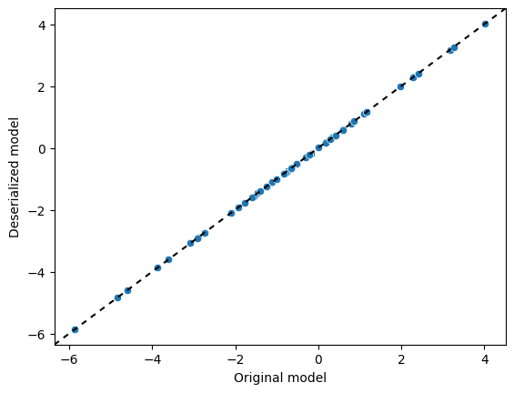

Compare parameter samples

```python
sigma2_df = pd.DataFrame(
    np.c_[
        bart_model.global_var_samples, bart_model_file_deserialized.global_var_samples
    ],
    columns=["Original model", "Deserialized model"],
)
sns.scatterplot(data=sigma2_df, x="Original model", y="Deserialized model")
plt.axline((0, 0), slope=1, color="black", linestyle=(0, (3, 3)))
plt.show()
```

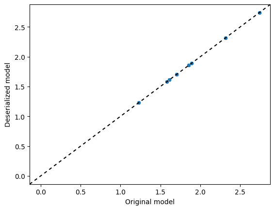

Clean up JSON file

```python
os.remove("bart.json")
```